# Introduction to Neural Networks: Bank Churn Prediction Porject 7

### Model 2

```python
backend.clear_session()
np.random.seed(42)
import random
random.seed(42)
tf.random.set_seed(42)
```

```python
model2 = Sequential()
model2.add(Dense(128,activation='relu',input_dim = X_train.shape[1]))
model2.add(BatchNormalization())
model2.add(Dense(64,activation='relu',kernel_initializer='he_uniform'))
model2.add(BatchNormalization())
model2.add(Dense(32,activation='relu',kernel_initializer='he_uniform'))
model2.add(Dense(1, activation = 'sigmoid'))
```

```python
model2.summary()
```

```
Model: "sequential"
_________________________________________________________________
 Layer (type)                Output Shape              Param #
=================================================================
 dense (Dense)               (None, 128)               2944

 batch_normalization (BatchN  (None, 128)              512
 ormalization)

 dense_1 (Dense)             (None, 64)                8256

 batch_normalization_1 (Batc  (None, 64)               256
 hNormalization)

 dense_2 (Dense)             (None, 32)                2080

 dense_3 (Dense)             (None, 1)                 33

=================================================================
Total params: 14,081
Trainable params: 13,697
Non-trainable params: 384
_________________________________________________________________
```

```python
optimizer = tf.keras.optimizers.Adam(0.001)
model2.compile(loss='binary_crossentropy',optimizer=optimizer,metrics=[recall])
```

```python
history_2 = model2.fit(X_train,y_train,batch_size=64,epochs=50,verbose=1,validation_split = 0.2)
```

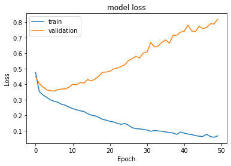

```python
#Plotting Train Loss vs Validation Loss
plt.plot(history_2.history['loss'])
plt.plot(history_2.history['val_loss'])
plt.title('model loss')
plt.ylabel('Loss')
plt.xlabel('Epoch')
plt.legend(['train', 'validation'], loc='upper left')
plt.show()
```

```
Best Threshold=0.018523, G-Mean=0.736
```

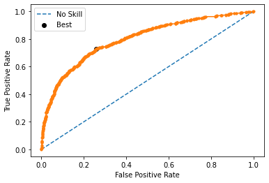

```python
# predict probabilities
yhat2 = model2.predict(X_val)
# keep probabilities for the positive outcome only
yhat2 = yhat2[:, 0]
# calculate roc curves
fpr, tpr, thresholds2 = roc_curve(y_val, yhat2)
# calculate the g-mean for each threshold
gmeans2 = np.sqrt(tpr * (1-fpr))
# locate the index of the largest g-mean
ix = np.argmax(gmeans2)
print('Best Threshold=%f, G-Mean=%.3f' % (thresholds2[ix], gmeans2[ix]))
# plot the roc curve for the model
pyplot.plot([0,1], [0,1], linestyle='--', label='No Skill')
pyplot.plot(fpr, tpr, marker='.')
pyplot.scatter(fpr[ix], tpr[ix], marker='o', color='black', label='Best')
# axis labels
pyplot.xlabel('False Positive Rate')
pyplot.ylabel('True Positive Rate')
pyplot.legend()
# show the plot
pyplot.show()
```

```python
y_pred_e2=model2.predict(X_val)
y_pred_e2 = (y_pred_e2 > thresholds2[ix])
y_pred_e2
```

```
array([[False],
       [False],
       [False],
       ...,
       [False],
       [False],
       [False]])
```

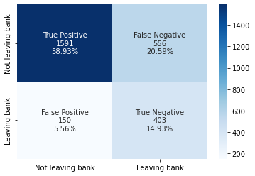

```python
#Calculating the confusion matrix
from sklearn.metrics import confusion_matrix
cm2=confusion_matrix(y_val, y_pred_e2)
labels = ['True Positive','False Negative','False Positive','True Negative']
categories = [ 'Not leaving bank','Leaving bank']
make_confusion_matrix(cm2,
                      group_names=labels,
                      categories=categories,
                      cmap='Blues')
```

```python
#Accuracy as per the classification report
from sklearn import metrics
cr2_tr=metrics.classification_report(y_val,y_pred_e2)
print(cr2_tr)
```

```
              precision    recall  f1-score   support

           0       0.91      0.74      0.82      2147
           1       0.42      0.73      0.53       553

    accuracy                           0.74      2700
   macro avg       0.67      0.73      0.68      2700
weighted avg       0.81      0.74      0.76      2700
```

### Check for overfitting on Model 2

```python
y_pred_e2_tr=model2.predict(X_train)
y_pred_e2_tr = (y_pred_e2_tr > thresholds2[ix])
y_pred_e2_tr
```

```
array([[False],
       [False],
       [ True],
       ...,
       [ True],
       [ True],
       [ True]])
```

```python
from sklearn import metrics
cr2=metrics.classification_report(y_train,y_pred_e2_tr)
print(cr2)
```

```
              precision    recall  f1-score   support

           0       0.98      0.85      0.91      5022
           1       0.61      0.94      0.74      1278

    accuracy                           0.87      6300
   macro avg       0.80      0.89      0.83      6300
weighted avg       0.91      0.87      0.88      6300
```

##### Evalution

Recall on Model 2 - train os 94% whereas recall on Model 2 - val is 73%; Model 2 is overfitting

## Actionable Insights and Recommendations

- Key takeaways for the business

##### Build a program for at-risk customers using data to identify which customers as most at-risk for churn

- Build a machine learning classification model, such as logistic regression or decision tree, and then use the model to generate a list of most informative features.
- Use the features identified in this report - Age, Number of Products, Geography, Gender, Is Active Member as a guide in identifying at-risk customers
- The models in this report are overfitting; build additional models using other techniques, in order to find the best model that does not overfit the data while improving the recall score
- Seek to simplify the model through more in-depth feature analysis and feature enginnering